# Broadband Index

Ian Evans

2/17/2018

# Broadband Index

## Overview

For my data collection task I decided to collect data of broadband prices throughout the world. I got the idea based on an interesting index called the Big Mac index that is used to show PPP and that in the long-run exchange rates will equalize to that of the prices of identical baskets of goods and servies (in this case Broadband). I visited various websites first to find the echange rates between the USD and all the other world currencies. After having this list I then searched for information on broadband prices throughout the world. I found an article that actually compared the prices of broadband to the USD around the world, but did not include the exchange rate of the USD. After finding the broadband price rankings I inputted the exchange rate to form my csv file. This study aims to see whther or not Broadband is as effective if not more effective than the Big Mac Index in measuring whther or not currencies are at their proper levels.

## Data dictionary

```r
 broadband <- read_csv("https://raw.githubusercontent.com/ie3ni/ian-evans-repository/master/broadband_index.csv")
```

## Exploratory Analysis

```
## [1] "Russian Federation" "Israel"             "Latvia"
## [4] "Slovakia"           "Turkey"             "Mexico"
```

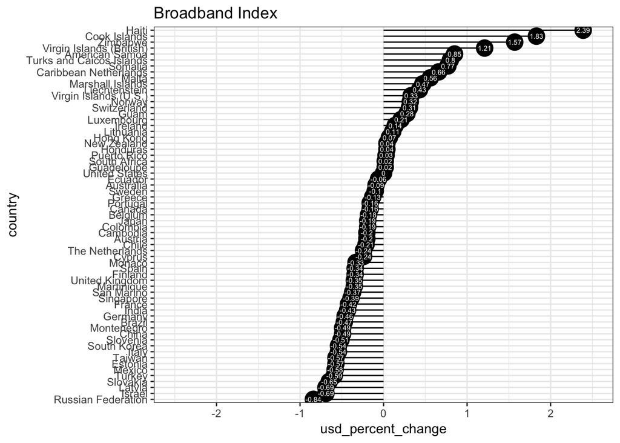

## Analysis

The graph above is a diverging lollipop chart that shows the percentage change in usd from the price of broadband packages throughout the world using different currencies. We then converted all the local currency prices of the broadband packages into usd. Form usd we could construct the graph above that shows which countries have overvalued currencies if we beleieve that broadband is a good measure of purchasing power parity. The countries who have a positive percentage change have currencies that are overvalued. The countries who have negative percentage changes have currencies that are undervalued. From further analysis we can see that the Yen and Euro are undervalued meanwhile the Swiss Franc is overvalued. From these postions we can then tailor our investment strategy to either short sell the overvalued currencies or go buy and go long on the undervalued currencies.

```
## [1] "Russian Federation" "Israel"             "Latvia"
## [4] "Slovakia"           "Turkey"             "Mexico"
```

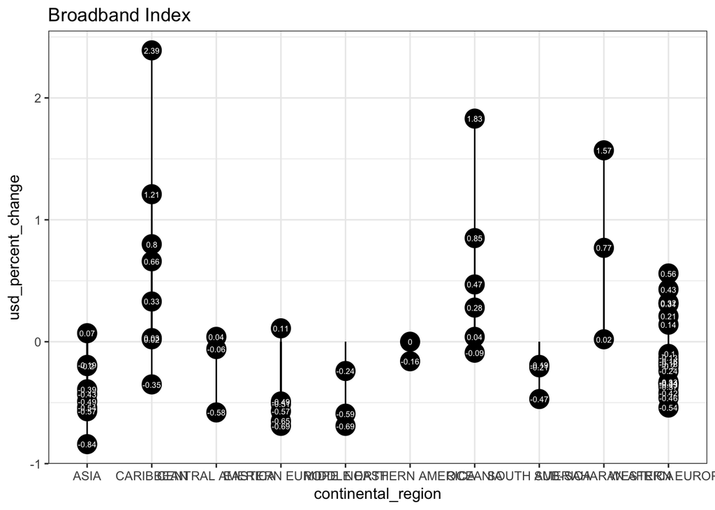

## Analysis

We can see the changes in usd percantage however this graph illustrates the changes within certain continental regions. By measuring the regions we can get a more generalized view of how the region of that economy is doing independent of the country. We can also see the groupings of currencies more clearly as of course countries in the same continent are more likely to use a currency that their neighbors use. It is interesting to note that in the Carribean islands the usd is highly inflated. This may not be due to the overvaluation of the dollar but due to the high export and import costs of the islands in the Caribbean. The isolation and difficulty of transportation raises these costs and looks as if the USD is overvalued when it is not.

## References

McCarthy, Niall. ‘The Most And Least Expensive Countries For Broadband [Infographic].’ Forbes, Forbes Magazine, 22 Nov. 2017, www.forbes.com/sites/niallmccarthy/2017/11/22/the-most-and-least-expensive-countries-for-broadband-infographic/#3d96914c23ef.